# R Notebook

# House Sales in King County, USA

This dataset contains house sale prices for King County, which includes Seattle. It includes homes sold between May 2014 and May 2015.

| **Variable** | **Description** |
| --- | --- |
| id | A notation for a house |
| date | Date house was sold |
| price | Price is prediction target |
| bedrooms | Number of bedrooms |
| bathrooms | Number of bathrooms |
| sqft_living | Square footage of the home |
| sqft_lot | Square footage of the lot |
| floors | Total floors (levels) in house |
| waterfront | House which has a view to a waterfront |
| view | Has been viewed |
| condition | How good the condition is overall |
| grade | overall grade given to the housing unit, based on King County grading system |
| sqft_above | Square footage of house apart from basement |
| sqft_basement | Square footage of the basement |
| yr_built | Built Year |
| yr_renovated | Year when house was renovated |
| zipcode | Zip code |
| lat | Latitude coordinate |
| long | Longitude coordinate |
| sqft_living15 | Living room area in 2015(implies-- some renovations) This might or might not have affected the lotsize area |
| sqft_lot15 | LotSize area in 2015(implies-- some renovations) |

If you run the lab locally using Anaconda, you can load the correct library and versions by uncommenting the following:

```python
# All Libraries required for this lab are listed below. The libraries pre-installed on Skills Network Labs are commented.
# !mamba install -qy pandas==1.3.4 numpy==1.21.4 seaborn==0.9.0 matplotlib==3.5.0 scikit-learn==0.20.1
# Note: If your environment doesn't support "!mamba install", use "!pip install"
```

```python
#  # Surpress warnings:
# def warn(*args, **kwargs):
#     pass
# import warnings
# warnings.warn = warn
```

You will require the following libraries:

```python
# import piplite
# await piplite.install(['pandas','matplotlib','scikit-learn','seaborn', 'numpy'])
```

```python
import pandas as pd
import matplotlib.pyplot as plt
import numpy as np
import seaborn as sns
from sklearn.pipeline import Pipeline
from sklearn.preprocessing import StandardScaler,PolynomialFeatures
from sklearn.linear_model import LinearRegression
# %matplotlib inline
```

# Module 1: Importing Data Sets

The functions below will download the dataset into your browser:

```python
# from pyodide.http import pyfetch
#
# async def download(url, filename):
#     response = await pyfetch(url)
#     if response.status == 200:
#         with open(filename, "wb") as f:
#             f.write(await response.bytes())
```

```python
file_name='https://cf-courses-data.s3.us.cloud-object-storage.appdomain.cloud/IBMDeveloperSkillsNetwork-DA0101EN-SkillsNetwork/labs/FinalModule_Coursera/data/kc_house_data_NaN.csv'
```

You will need to download the dataset; if you are running locally, please comment out the following code:

```python
# await download(file_name, "kc_house_data_NaN.csv")
# file_name="kc_house_data_NaN.csv"
```

Use the Pandas method **read_csv()** to load the data from the web address.

```python
df = pd.read_csv(file_name)
```

```python
df.head()
```

```
   Unnamed: 0          id             date  ...     long  sqft_living15  sqft_lot15
0           0  7129300520  20141013T000000  ... -122.257           1340        5650
1           1  6414100192  20141209T000000  ... -122.319           1690        7639
2           2  5631500400  20150225T000000  ... -122.233           2720        8062
3           3  2487200875  20141209T000000  ... -122.393           1360        5000
4           4  1954400510  20150218T000000  ... -122.045           1800        7503

[5 rows x 22 columns]
```

### Question 1

Display the data types of each column using the function dtypes, then take a screenshot and submit it, include your code in the image.

```python
df.dtypes
```

```
Unnamed: 0         int64
id                 int64
date              object
price            float64
bedrooms         float64
bathrooms        float64
sqft_living        int64
sqft_lot           int64
floors           float64
waterfront         int64
view               int64
condition          int64
grade              int64
sqft_above         int64
sqft_basement      int64
yr_built           int64
yr_renovated       int64
zipcode            int64
lat              float64
long             float64
sqft_living15      int64
sqft_lot15         int64
dtype: object
```

We use the method describe to obtain a statistical summary of the dataframe.

```python
df.describe()
```

```
        Unnamed: 0            id  ...  sqft_living15     sqft_lot15
count  21613.00000  2.161300e+04  ...   21613.000000   21613.000000
mean   10806.00000  4.580302e+09  ...    1986.552492   12768.455652
std     6239.28002  2.876566e+09  ...     685.391304   27304.179631
min        0.00000  1.000102e+06  ...     399.000000     651.000000
25%     5403.00000  2.123049e+09  ...    1490.000000    5100.000000
50%    10806.00000  3.904930e+09  ...    1840.000000    7620.000000
75%    16209.00000  7.308900e+09  ...    2360.000000   10083.000000
max    21612.00000  9.900000e+09  ...    6210.000000  871200.000000

[8 rows x 21 columns]
```

# Module 2: Data Wrangling

### Question 2

Drop the columns `"id"` and `"Unnamed: 0"` from axis 1 using the method `drop()`, then use the method `describe()` to obtain a statistical summary of the data. Take a screenshot and submit it, make sure the `inplace` parameter is set to `True`

```python
df.drop(["id", "Unnamed: 0"], axis = 1, inplace = True)
df.describe()
```

```
              price      bedrooms  ...  sqft_living15     sqft_lot15
count  2.161300e+04  21600.000000  ...   21613.000000   21613.000000
mean   5.400881e+05      3.372870  ...    1986.552492   12768.455652
std    3.671272e+05      0.926657  ...     685.391304   27304.179631
min    7.500000e+04      1.000000  ...     399.000000     651.000000
25%    3.219500e+05      3.000000  ...    1490.000000    5100.000000
50%    4.500000e+05      3.000000  ...    1840.000000    7620.000000
75%    6.450000e+05      4.000000  ...    2360.000000   10083.000000
max    7.700000e+06     33.000000  ...    6210.000000  871200.000000

[8 rows x 19 columns]
```

We can see we have missing values for the columns `bedrooms` and `bathrooms`

```python
print("number of NaN values for the column bedrooms :", df['bedrooms'].isnull().sum())
```

```
number of NaN values for the column bedrooms : 13
```

```python
print("number of NaN values for the column bathrooms :", df['bathrooms'].isnull().sum())
```

```
number of NaN values for the column bathrooms : 10
```

We can replace the missing values of the column `'bedrooms'` with the mean of the column `'bedrooms'` using the method `replace()`. Don’t forget to set the `inplace` parameter to `True`

```python
mean=df['bedrooms'].mean()
df['bedrooms'].replace(np.nan,mean, inplace=True)
```

We also replace the missing values of the column `'bathrooms'` with the mean of the column `'bathrooms'` using the method `replace()`. Don’t forget to set the `inplace` parameter top `True`

```python
mean=df['bathrooms'].mean()
df['bathrooms'].replace(np.nan,mean, inplace=True)
```

```python
print("number of NaN values for the column bedrooms :", df['bedrooms'].isnull().sum())
```

```
number of NaN values for the column bedrooms : 0
```

```python
print("number of NaN values for the column bathrooms :", df['bathrooms'].isnull().sum())
```

```
number of NaN values for the column bathrooms : 0
```

# Module 3: Exploratory Data Analysis

### Question 3

Use the method `value_counts` to count the number of houses with unique floor values, use the method `.to_frame()` to convert it to a dataframe.

```python
df['floors'].value_counts().to_frame()
```

```
     floors
1.0   10680
2.0    8241
1.5    1910
3.0     613
2.5     161
3.5       8
```

### Question 4

Use the function `boxplot` in the seaborn library to determine whether houses with a waterfront view or without a waterfront view have more price outliers.

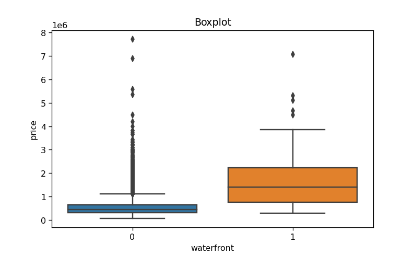

```python
plt.clf()
sns.boxplot(x = 'waterfront', y = 'price', data = df)
plt.title("Boxplot")
plt.show()
```

### Question 5

Use the function `regplot` in the seaborn library to determine if the feature `sqft_above` is negatively or positively correlated with price.

```python
plt.clf()
width = 12
height= 10
plt.figure(figsize = (width, height))
sns.regplot(x = 'sqft_above', y = 'price', data = df)
plt.ylim(0,)
```

```
(0.0, 8081250.0)
```

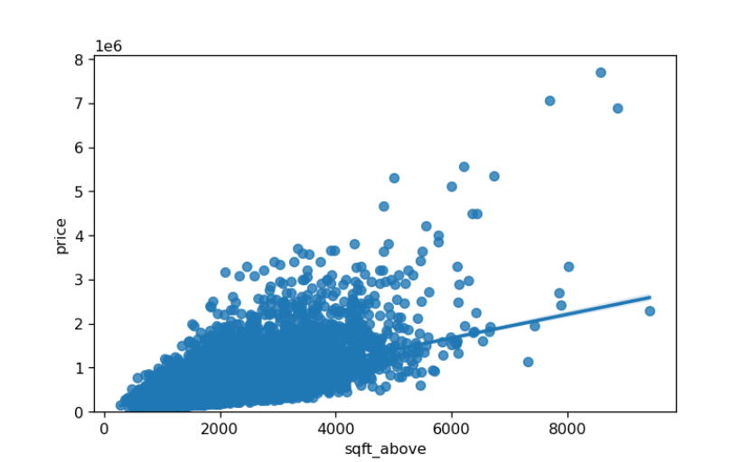

```python
plt.show()
```

We can use the Pandas method `corr()` to find the feature other than price that is most correlated with price.

```python
df.corr()['price'].sort_values()
```

```
zipcode         -0.053203
long             0.021626
condition        0.036362
yr_built         0.054012
sqft_lot15       0.082447
sqft_lot         0.089661
yr_renovated     0.126434
floors           0.256794
waterfront       0.266369
lat              0.307003
bedrooms         0.308797
sqft_basement    0.323816
view             0.397293
bathrooms        0.525738
sqft_living15    0.585379
sqft_above       0.605567
grade            0.667434
sqft_living      0.702035
price            1.000000

Name: price, dtype: float64
```

# Module 4: Model Development

We can Fit a linear regression model using the longitude feature `'long'` and caculate the R^2.

```python
X = df[['long']]
Y = df[['price']]
lm = LinearRegression()
lm.fit(X,Y)
```

```
LinearRegression()
```

```python
lm.score(X, Y)
```

```
0.00046769430149007363
```

### Question 6

Fit a linear regression model to predict the `'price'` using the feature `'sqft_living'` then calculate the R^2. Take a screenshot of your code and the value of the R^2.

```python
X = df[['sqft_living']]
Y = df[['price']]
lm = LinearRegression()
lm.fit(X,Y)
```

```
LinearRegression()
```

```python
lm.score(X, Y)
```

```
0.4928532179037931
```

### Question 7

Fit a linear regression model to predict the `'price'` using the list of features:

```python
features =df[["floors", "waterfront","lat" ,"bedrooms" ,"sqft_basement" ,"view" ,"bathrooms","sqft_living15","sqft_above","grade","sqft_living"]]
```

```python
Y = df['price']
lm = LinearRegression()
lm.fit(features, Y)
```

```
LinearRegression()
```

Then calculate the R^2. Take a screenshot of your code.

```python
lm.score(features, Y)
```

```
0.6576862276276761
```

### This will help with Question 8

Create a list of tuples, the first element in the tuple contains the name of the estimator:

- `'scale'`
- `'polynomial'`
- `'model'`

The second element in the tuple contains the model constructor

`StandardScaler()`

`PolynomialFeatures(include_bias=False)`

`LinearRegression()`

```python
Input=[('scale',StandardScaler()),('polynomial', PolynomialFeatures(include_bias=False)),('model',LinearRegression())]
```

### Question 8

Use the list to create a pipeline object to predict the ‘price’, fit the object using the features in the list `features`, and calculate the R^2.

```python
pipe = Pipeline(Input)
features = features.astype(float)
pipe.fit(features, Y)
```

```
Pipeline(steps=[('scale', StandardScaler()),
                ('polynomial', PolynomialFeatures(include_bias=False)),
                ('model', LinearRegression())])
```

```python
pipe.score(features, Y)
```

```
0.7513405086047977
```

# Module 5: Model Evaluation and Refinement

Import the necessary modules:

```python
from sklearn.model_selection import cross_val_score
from sklearn.model_selection import train_test_split
print("done")
```

```
done
```

We will split the data into training and testing sets:

```python
train_test_split(X, Y, test_size=0.15, random_state=1)
```

[output not shown]

[output cut: 34 more lines]

### Question 9

```python
from sklearn.linear_model import Ridge
```

```python
RidgeModel = Ridge(alpha = 1)
RidgeModel.fit(x_train, y_train)
```

```
Ridge(alpha=1)
```

```python
RidgeModel.score(x_test, y_test)
```

```
0.6478078664848201
```

### Question 10

```python
pr = PolynomialFeatures(degree = 2)
x_train_pr = pr.fit_transform(x_train[features])
x_test_pr = pr.fit_transform(x_test[features])

RidgeModel = Ridge(alpha = 1)
RidgeModel.fit(x_train_pr, y_train)
```

```
Ridge(alpha=1)
```

```python
RidgeModel.score(x_test_pr, y_test)
```

```
0.6996769635406714
```

Once you complete your notebook you will have to share it. Select the icon on the top right a marked in red in the image below, a dialogue box should open, and select the option all content excluding sensitive code cells.

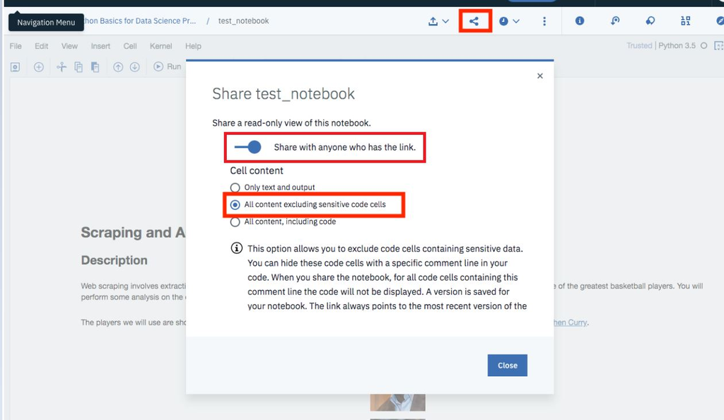

share notebook

You can then share the notebook via a URL by scrolling down as shown in the following image:

[figure not shown]